# Blackjack

Xingche Guo

6/6/2024

This .Rmd file use the Blackjack example (example 5.1 in the RL book) to illustrate Monte Carlo method for pursuing optimal policy.

Different from the book, in this file, the dealer’s policy is: **stick** if
$$\text{dealer sum} \ge 18 \quad \mbox{or} \quad \text{dealer sum} = 17 \ \ \mbox{with no ace}.$$

According to the book, the state of the MDP is:
$$\text{state} =(\text{player sum}, \ \text{dealer showing}, \ \text{usable ace}),$$
We only need to evaluate
$$12 \le \text{player sum} \le 20.$$

This is because when $\text{player sum} \le 11$, we always hit; when $\text{player sum} = 21$, we always stick.

## Monte Carlo method with exploring start

To evaluate $Q(s, a)$, note that we are unlikely to evaluate every state-action pair for an deterministic policy. Therefore, we **randomly explore all possible states/actions at the beginning of the game** to ensure observations for all the state-action pairs.

To do that, we randomly generate the initial (three-dimensional) states from a uniform distribution to ensure each state have enough observations. We randomly simulate the first action to be **hit/stick** with equal probabilities and ther rest actions following the current policy to be evaluated.

Suppose $\widehat{Q}^{(l)}(s,a)$ is the Monte Carlo estimate of $Q(s,a)$ at the $l$-th iteration. For the stability of the algorithm, we let
$$\widetilde{Q}^{(l+1)}(s,a) \leftarrow \alpha\widehat{Q}^{(l+1)}(s,a) + (1-\alpha)\widetilde{Q}^{(l)}(s,a). \quad\quad(1)$$
Then we improve the (deterministic) policy by
$$\pi_l(a \mid s) = \mbox{argmax}_a \widetilde{Q}^{(l)}(s,a).$$

The optimal policy is shown below:

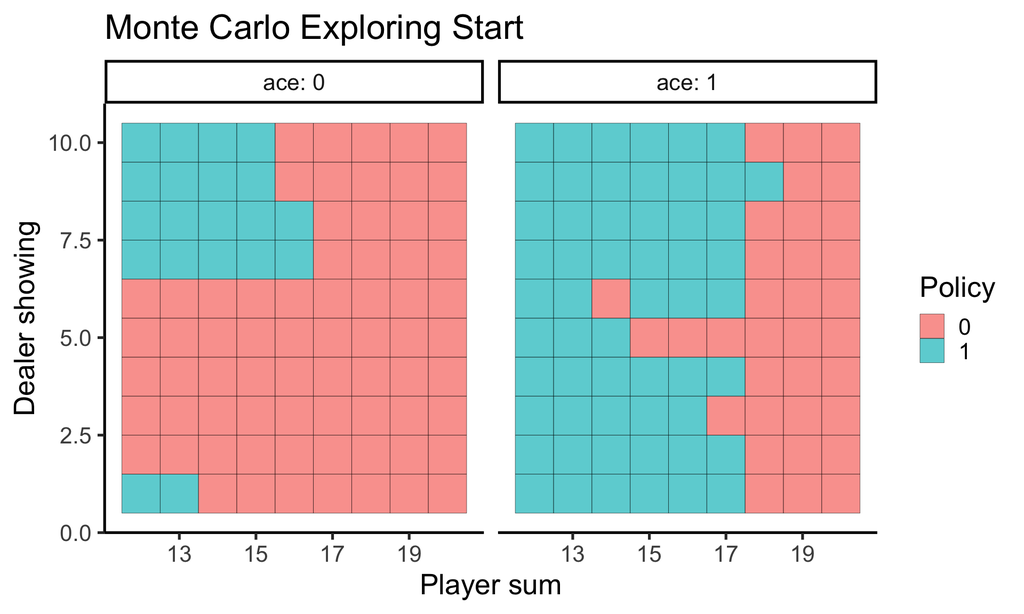

```r
library(ggplot2)
source("generate_blackjack_episode.R")
policy_explore_start <- readRDS("policy_explore_start.rds")

####################### visualize optimal policy #################
ggplot(data = policy_explore_start) +
  geom_tile(aes(x = count, y = dealer_card, fill = as.factor(a_new)),
            colour = "black", alpha=0.7) +
  facet_wrap(~ace, ncol=2, labeller = label_both) +
  scale_fill_discrete(name="Policy") +
  xlab("Player sum") +
  ylab("Dealer showing") +
  ggtitle("Monte Carlo Exploring Start") +
  theme_classic(base_size = 20)
```

## Monte Carlo method with $\epsilon$-soft policy

Another way to ensure observations for all the state-action pairs, is to use stochastic policies. The $\epsilon$-soft version of policy $\pi(a \mid s)$ is
$$\pi_{\epsilon}(a \mid s) = (1 - \epsilon) \pi(a \mid s) + \epsilon \frac{1}{| \mathcal{A}|}.$$
Still, we generate the initial (three-dimensional) states from a uniform distribution to ensure each state have enough observations. At the same time, we apply (1) again for the stability of the algorithm. Using an $\epsilon$-soft policy is guaranteed to increase the value function (referred to the RL book).

The optimal policy (deterministic version) is shown below:

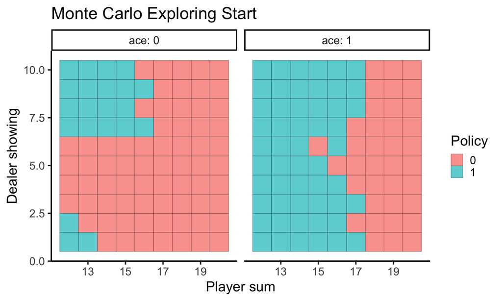

```r
policy_epsilon_soft <- readRDS("policy_epsilon_soft.rds")

####################### visualize optimal policy #################
ggplot(data = policy_epsilon_soft) +
  geom_tile(aes(x = count, y = dealer_card, fill = as.factor(a_new)),
            colour = "black", alpha=0.7) +
  facet_wrap(~ace, ncol=2, labeller = label_both) +
  scale_fill_discrete(name="Policy") +
  xlab("Player sum") +
  ylab("Dealer showing") +
  ggtitle("Monte Carlo Exploring Start") +
  theme_classic(base_size = 20)
```

## Compare different policies

```r
## function for any deterministic policy.
policy_player_deterministic <- function(s, y, ace, ref){
  if (s==21){
    return (0)
  } else if (s <=11) {
    return (1)
  } else {
    idx <- which(s==ref$count & y==ref$dealer_card & ref$ace==ace)
    return(ref$a_new[idx])
  }
}


## player's policy (random actions with p=0.5)
policy_player_random <- function(s=NULL, y=NULL, ace=NULL, ref=NULL){
  #s: count of player's cards;
  #y: dealer's first card;
  #ace: [true/false] whether player have usable ace).
  return(rbinom(1, 1, 0.5))
}


## player's policy (same as dealer)
policy_player_dealer <- function(s, y=NULL, ace, ref=NULL){
  #s: count of player's cards;
  #y: dealer's first card;
  #ace: [true/false] whether player have usable ace).
  if (s >= 18){
    return (0)
  } else if ( (s==17) & (ace==0)){
    return (0)
  } else {
    return (1)
  }
}

## player's policy (optimal based on the book)
policy_player_optimal <- function(s, y, ace, ref=NULL){
  #s: count of player's cards;
  #y: dealer's first card;
  #ace: [true/false] whether player have usable ace).
  if (ace){
    if (y>=2 & y<=8){
      a <- ifelse(s>=18, 0, 1)
    } else {
      a <- ifelse(s>=19, 0, 1)
    }
  } else {
    if (y<=1 | y>=7){
      a <- ifelse(s>=16, 0, 1)
    } else if (y>=2 & y<=3){
      a <- ifelse(s>=13, 0, 1)
    } else {
      a <- ifelse(s>=12, 0, 1)
    }
  }
  return(a)
}



############## compare different policies ##############
N <- 5e5

## random
R1 <- rep(0, N)
for (i in 1:N){
  episode <- play_blackjack(policy_player=policy_player_random)
  R1[i] <- episode$r
}
table(R1) / N
```

```
## R1
##       -1        0        1
## 0.656802 0.038878 0.304320
```

```r
mean(R1)
```

```
## [1] -0.352482
```

```r
## dealer
R2 <- rep(0, N)
for (i in 1:N){
  episode <- play_blackjack(policy_player=policy_player_my)
  R2[i] <- episode$r
}
table(R2) / N
```

```
## R2
##       -1        0        1
## 0.496068 0.096032 0.407900
```

```r
mean(R2)
```

```
## [1] -0.088168
```

```r
## RL book
R3 <- rep(0, N)
for (i in 1:N){
  episode <- play_blackjack(policy_player=policy_player_optimal)
  R3[i] <- episode$r
}
table(R3) / N
```

```
## R3
##       -1        0        1
## 0.485590 0.080722 0.433688
```

```r
mean(R3)
```

```
## [1] -0.051902
```

```r
## MC explore start
R4 <- rep(0, N)
for (i in 1:N){
  episode <- play_blackjack(policy_player=policy_player_deterministic,
                            policy_explore_start)
  R4[i] <- episode$r
}
table(R4) / N
```

```
## R4
##       -1        0        1
## 0.484306 0.080964 0.434730
```

```r
mean(R4)
```

```
## [1] -0.049576
```

```r
## MC epsilon-soft
R5 <- rep(0, N)
for (i in 1:N){
  episode <- play_blackjack(policy_player=policy_player_deterministic,
                            policy_epsilon_soft)
  R5[i] <- episode$r
}
table(R5) / N
```

```
## R5
##       -1        0        1
## 0.483330 0.082648 0.434022
```

```r
mean(R5)
```

```
## [1] -0.049308
```

The results tell us: **Never play Blackjack alone with dealer especially if you cannot remember cards or there are too many decks of cards!**